# OpenStreetMapを背景にした情報通信業事業所数の可視化

東京都23区の例

[岩田真一郎](https://shinichiro-iwata.github.io/)（ [神奈川大学経済学部](https://www.econ.kanagawa-u.ac.jp/)）

2022-06-20作成，2024-08-10改訂

# 1 目的

東京都23区内の情報通信産業の集積状況を可視化．また応用として，[OpenStreetMap](https://www.openstreetmap.org/)の地図タイル画像を背景に用いる．

ライブラリ：`sf`，`tidyverse`

```r
library(sf)
library(tidyverse)
```

# 2 事業所数の可視化

**行政区域のダウンロード**

- [国土数値情報ダウンロードサービス](https://nlftp.mlit.go.jp/ksj/) > 行政区域（ポリゴン） > 東京都 > 令和3年
  - ダウンロードしたZIPファイルは同じフォルダー（ディレクトリ）に納め，ZIPファイルを選択 > 右クリック > すべて展開 > 展開先の選択とファイルの選択 > 展開を実行する．展開後は最初にダウンロードしたZIPファイルを削除．
  - `read_sf`：データ読込．行政区域を`Tokyo_map`と名付ける．
  - パイプ演算子（`%>%`）を使い，23区を抜き出し，`t23-wards_map`と名付ける．

```r
#東京都の地図
Tokyo_map <-
  read_sf("N03-20210101_13_GML/N03-20210101_13_GML/N03-21_13_210101.shp")

#世界測地系を指定
Tokyo_map <-
  Tokyo_map %>%
  st_transform("WGS84")

#23区の抽出
Tokyo_map %>%
  filter(N03_007>="13101" &
           N03_007<="13123") ->
  t23_wards_map
```

**統計データダウンロード**

- [統計地理情報システム](https://www.e-stat.go.jp/gis) > 統計データダウンロード > 経済センサス－活動調査 > 2016年 > 4次メッシュ（500mメッシュ） > 産業（大分類）別事業所数及び従業者数 > 東京都
  - 主に23区に注目．`M5339`をダウンロード．`economic`と名付ける
    - **文字化け**問題：文字コードの関係で，テキストファイルが適切に読み込めない場合がある（不正なマルチバイト文字 ．．．）．この場合は、`fileEncoding="CP932"`のオプションを加える（例えば`sep=1`の後に）．

```r
#ヘッダー（行の説明）あり，カンマ区切り
economic <-
  read.csv("tblT000918H5339/tblT000918H5339.txt",
           header=TRUE, sep=",",
           fileEncoding="CP932")

#便宜上1行目削除
economic %>%
  slice(-1) ->
  economic

#後ほど，統計データをメッシュ地図と結合するため，KEY_CODEを文字列に変更
economic %>%
  mutate(KEY_CODE=as.character(KEY_CODE)) ->
  economic
```

**境界データのダウンロード**

- [地図で見る統計（統計GIS）](https://www.e-stat.go.jp/gis) > 境界データダウンロード > 4次メッシュ（500mメッシュ） > 世界測地系緯度経度・Shapefile > 都道府県で絞込みはコチラ > 東京都
  - 統計データと対応したメッシュをダウンロード．`mesh`と名付ける．

```r
mesh <-
  read_sf("HDDSWH5339/MESH05339.shp")

#世界測地系を指定
mesh <-
  mesh %>%
  st_transform("WGS84")

#meshとeconomicを結合
mesh_economic <-
  left_join(mesh, economic, by=c("KEY_CODE"))
```

**メッシュ地図による事業所数の可視化**

- 情報通信業の事業所数は`T000918008`の列に含まれる．

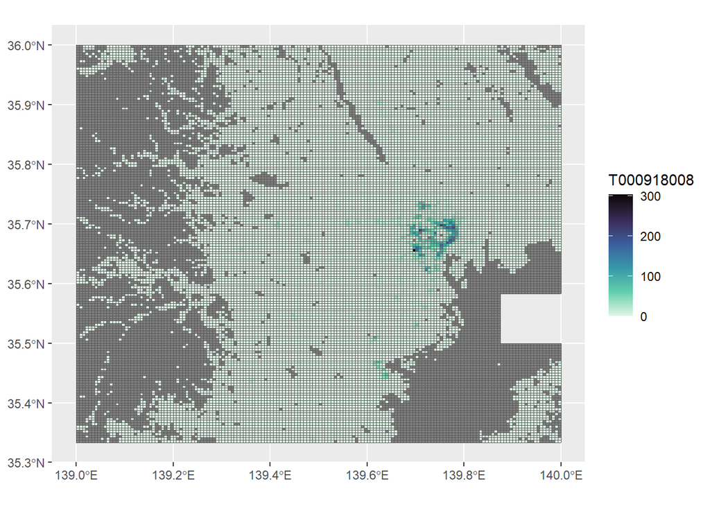

```r
#事業所数が文字情報になっている→整数に変更指示
mesh_economic %>%
  mutate(T000918008=as.integer(T000918008)) ->
  mesh_economic

#500mメッシュ事業所数の可視化
ggplot()+
  geom_sf(data=mesh_economic,
          aes(fill=T000918008))+
  scale_fill_viridis_c(option="G",
                       direction=-1)
```

**データ結合**

- 詳細は[コミュニティバス路線上の人口密度の可視化](https://shinichiro-iwata.github.io/geospatial-data-visualization/community-bus-visualization.html)参照．

```r
st_agr(mesh_economic)="constant"
st_agr(t23_wards_map)="constant"

#東京都23区の地図に事業所数が加わったメッシュデータの完成
mesh_economic_23 <-
  st_intersection(x=mesh_economic,
                  y=t23_wards_map)
```

# 3 東京都23区内の事業所数の可視化

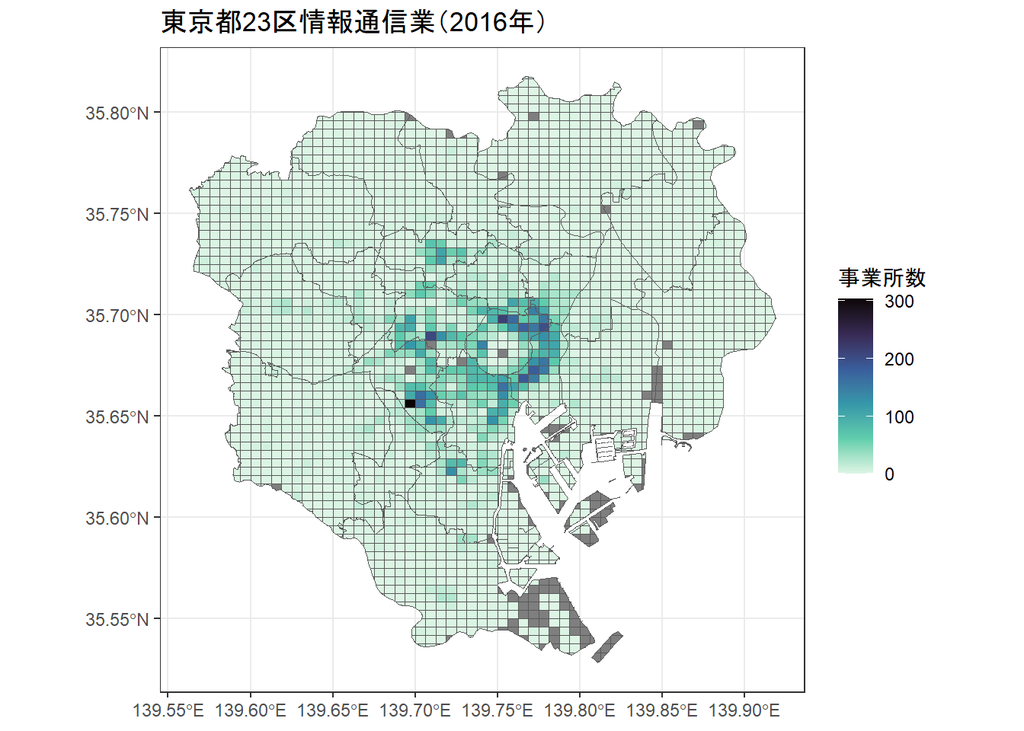

```r
ggplot()+
  geom_sf(data=mesh_economic_23,
          aes(fill=T000918008))+
  scale_fill_viridis_c(option="G",
                      direction=-1)+
  labs(fill="事業所数")+
  ggtitle("東京都23区情報通信業（2016年）")+
  theme_bw()
```

**参考**

東京都23区の行政区域の地名は以下の通り．

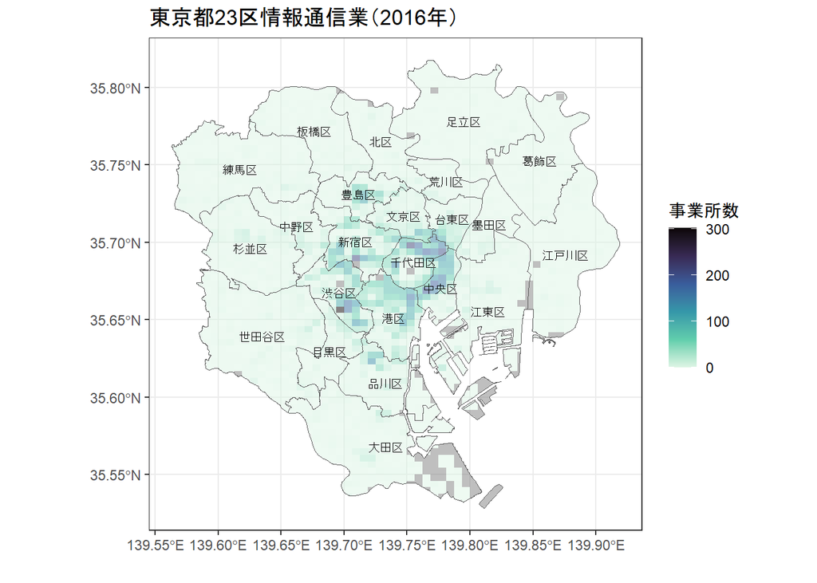

# 4 OpenStreetMapの活用

**OpenStreetMapの可視化**

背景としてOpenStreetMap（OSM）を利用．以下はBrunsdon & Comber（2018）356－357頁参照．

- `library()`でパッケージ`ggspatial`を呼び出す．
  - `annotation_map_tile()`：背景にOSMのタイルを使う．
  - `zoomin`：数が大きくなるほど拡大．初期値は`-2`．
- OSMを利用する際には地図の隅に[権利](https://www.openstreetmap.org/copyright/ja)を表示．
  - `labs(caption = "\U00a9 OpenStreetMap contributors")`．

[figure not shown]

```r
library(ggspatial)

#OSM活用
ggplot()+
  annotation_map_tile(zoomin=0)+
  geom_sf(data=mesh_economic_23, fill="NA")+
  labs(caption="\U00a9 OpenStreetMap contributors")+
  ggtitle("東京都23区周辺のOSM")
```

**完成図**

OSMの地図タイル画像を背景に事業所数を可視化．

- `alpha`で地図を透かすことにより，最背面のOSMの地図を見える化．
- `color=NA`でメッシュ（の枠）を透明に変更．
- `theme_void()`を指定することで，緯度経度なしに．
  - `labs()`にその他の出典も含め，`theme()`で左寄せにする．

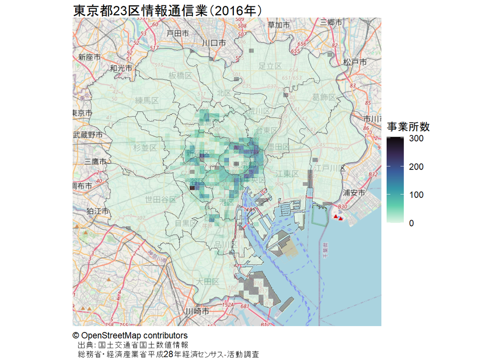

```r
#完成図
ggplot()+
  annotation_map_tile(zoomin=0)+
  geom_sf(data=mesh_economic_23,
          aes(fill=T000918008),
          alpha=0.7, color=NA)+
  scale_fill_viridis_c(option="G",
                       direction=-1)+
  geom_sf(data=t23_wards_map, fill="NA")+
  labs(fill="事業所数",
       caption="\U00a9 OpenStreetMap contributors
  出典：国土交通省国土数値情報
  総務省・経済産業省平成28年経済センサス‐活動調査")+
  ggtitle("東京都23区情報通信業（2016年）")+
  theme_void()+
  theme(plot.caption=element_text(hjust=0))
```

**参考文献**

- Brunsdon，C. & Comber, L. （訳：湯谷啓明・工藤和奏・市川太祐）（2018）. 『[Rによる地理空間データ解析入門](https://www.kyoritsu-pub.co.jp/book/b10003125.html)』「共立出版」

**Rによる地理空間データの可視化**

- チュートリアル[ホーム](https://shinichiro-iwata.github.io/geospatial-data-visualization/)